# **Problem:**

**Cash-Without-Borders A multi-national fintech company which offers payment solutions for private consumers as well as small- to medium-enterprises considers lowering their cost of technical support. The payment solution company has the strategy of offering payments transfers quick and in a hassle-free way. For technical support, the company consider the strategies: keep the support in-house as before, outsource to a call-centre in a third country or apply a specially trained chat- bot. The advantage of having the support in-house is that the company will lose high-value clients if the service becomes worse.**

### a) Do a SMART-analysis of the problem as described in Chapter 3, Decisions involving multiple objectives in the book Decision Analysis for Management Judgment on eStudy. Be sure to include a value-tree for the problem.

#### **SMART Analysis**

**Specific:** The objective is to lower the cost of technical support while maintaining a high quality of service to avoid losing high-value clients.

**Measurable:** The success can be measured by comparing the total costs of technical support and tracking customer satisfaction scores.

**Achievable:** The goal is achievable by either keeping the support in-house, outsourcing to a third country, or using a chatbot.

**Relevant:** Reducing costs is crucial for the company to remain competitive and profitable.

**Time-bound:** The decision should be implemented within a specific time frame, for instance, within the next fiscal year.

### **Alternatives:**

Keep support in-house Outsource to a call center in a third country Implement a specially trained chatbot

**Value tree**

The value tree for the problem can be divided into the main objective and sub-objectives that contribute to achieving the main goal.

**Main Objective:** Reduce technical support costs while maintaining service quality.:**

**Minimize Costs:** Staff salaries Operational expenses Training and development

**Maximize Customer Satisfaction:**

Response time Issue resolution effectiveness Personalization of service

**Manage Risk:**

Risk of losing high-value clients Risk of technical issues Risk of implementation delays

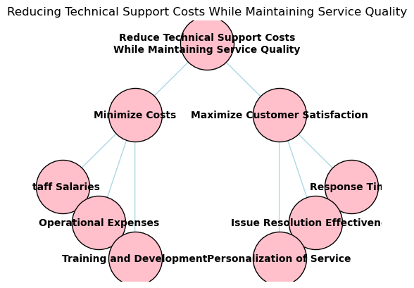

```python
import matplotlib.pyplot as plt
import networkx as nx

G = nx.DiGraph()

# Here we define the main objective and sub-objectives

main_objective = "Reduce Technical Support Costs\nWhile Maintaining Service Quality"
sub_objectives = ["Minimize Costs", "Maximize Customer Satisfaction"]
minimize_costs = ["Staff Salaries", "Operational Expenses", "Training and Development"]
maximize_satisfaction = ["Response Time", "Issue Resolution Effectiveness", "Personalization of Service"]

G.add_node(main_objective)
for sub in sub_objectives:
    G.add_node(sub)
    G.add_edge(main_objective, sub)

for mc in minimize_costs:
    G.add_node(mc)
    G.add_edge(sub_objectives[0], mc)

for ms in maximize_satisfaction:
    G.add_node(ms)
    G.add_edge(sub_objectives[1], ms)

pos = {
    main_objective: (0, 0),
    sub_objectives[0]: (-1, -1),
    sub_objectives[1]: (1, -1),
    minimize_costs[0]: (-2, -2),
    minimize_costs[1]: (-1.5, -2.5),
    minimize_costs[2]: (-1, -3),
    maximize_satisfaction[0]: (2, -2),
    maximize_satisfaction[1]: (1.5, -2.5),
    maximize_satisfaction[2]: (1, -3),
}

# Here we draw the nodes

nx.draw_networkx_nodes(G, pos, node_size=3000, node_color='pink', edgecolors='black')

# Here we draw the edges

nx.draw_networkx_edges(G, pos, arrowstyle='->', arrowsize=20, edge_color='lightblue')

# Here we draw the labels

nx.draw_networkx_labels(G, pos, font_size=10, font_color='black', font_weight='bold')


plt.title("Reducing Technical Support Costs While Maintaining Service Quality")

#Here we display the plot

plt.axis('off')
plt.show()
```

### b) Briefly describe how you would go about to estimate the costs and risks of the activities in you value-tree.

To estimate the costs and risks, we would:

**In-house support costs:** Calculate the current expenditure on salaries, training, infrastructure, and other overheads. Estimate future costs based on current trends.

**Outsourcing costs:** Obtain quotes from third-country call centers, including initial setup costs, ongoing operational costs, and any additional fees for high-quality service.

**Chatbot costs:** Estimate the cost of developing and maintaining a chatbot, including initial development, regular updates, and occasional human intervention.

**Customer satisfaction:** Conduct surveys or analyze customer feedback to estimate the impact of each strategy on customer satisfaction.

**Risk analysis:** Identify potential risks for each strategy. Assign probabilities to each risk and estimate the potential financial impact. For instance, the risk of losing high-value clients can be estimated by the proportion of high-value clients and the potential revenue loss.

### c) Explain how you would find the maximum expected monetary value of the three main strategies in this case. Demonstrate your solution (either with a probability tree or through a Monte-Carlo simulation) on pen and paper or with Python code. In the answer you are required to show how you have attributed costs and risks (either probabilities or distribution of probabilities) for each uncertain cost. You should also give (made-up) monetary costs for each strategy.

**Cost Estimates:**

In-house support: $1,000,000 per year

Outsourcing: $600,000 per year

Chatbot: $300,000 per year

**Risk Estimates:**

Probability of losing high-value clients (In-house): 5%, cost impact: $500,000

Probability of losing high-value clients (Outsourcing): 15%, cost impact: $500,000

Probability of losing high-value clients (Chatbot): 10%, cost impact: $500,000

**Quality of Service Estimates (Customer Satisfaction Impact):**

In-house: High satisfaction, no additional cost

Outsourcing: Medium satisfaction, additional cost to mitigate impact: $100,000

Chatbot: Low to medium satisfaction, additional cost to mitigate impact: $150,000

### **Probability Tree Calculation:**

**In-house support:**

Base cost=1,000,000

Risk cost=0.05×500,000=25,000

Total EMV=1,000,000+25,000=1,025,000

**Outsourced support:**

Base cost=600,000+100,000=700,000

Risk cost=0.15×500,000=75,000

Total EMV=700,000+75,000=775,000

**Chatbot support:**

Base cost=300,000+150,000=450,000

Risk cost=0.10×500,000=50,000

Total EMV=450,000+50,000=500,000

**Final EMVs:**

EMV In-house: $1,025,000

EMV Outsourced: $775,000

EMV Chatbot: $500,000

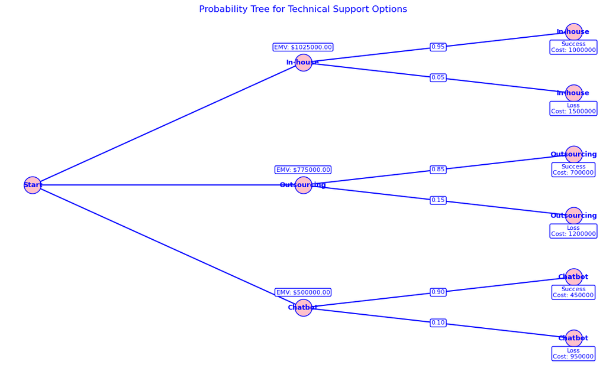

```python
import matplotlib.pyplot as plt

# Here we have the calculated EMVs

emv_in_house = 1025000.00
emv_outsourced = 775000.00
emv_chatbot = 500000.00

# Here we define the initial costs, risk probabilities, and quality of service costs

initial_costs = {
    "In-house support": 1000000,
    "Outsourcing": 600000,
    "Chatbot": 300000
}

risk_data = {
    "In-house support": {"probability": 0.05, "impact": 500000},
    "Outsourcing": {"probability": 0.15, "impact": 500000},
    "Chatbot": {"probability": 0.10, "impact": 500000}
}

quality_costs = {
    "In-house support": 0,
    "Outsourcing": 100000,
    "Chatbot": 150000
}

# Here we create the probability tree

plt.figure(figsize=(14, 8))

# Here we define the positions for the nodes

positions = {
    "Start": (0, 0),
    "In-house support": (2, 4),
    "Outsourcing": (2, 0),
    "Chatbot": (2, -4),
    "In-house success": (4, 5),
    "In-house loss": (4, 3),
    "Outsourcing success": (4, 1),
    "Outsourcing loss": (4, -1),
    "Chatbot success": (4, -3),
    "Chatbot loss": (4, -5),
}

# Here we define the edges and labels

edges = [
    ("Start", "In-house support"),
    ("Start", "Outsourcing"),
    ("Start", "Chatbot"),
    ("In-house support", "In-house success"),
    ("In-house support", "In-house loss"),
    ("Outsourcing", "Outsourcing success"),
    ("Outsourcing", "Outsourcing loss"),
    ("Chatbot", "Chatbot success"),
    ("Chatbot", "Chatbot loss"),
]

labels = {
    "In-house success": f"Success\nCost: {initial_costs['In-house support'] + quality_costs['In-house support']}",
    "In-house loss": f"Loss\nCost: {initial_costs['In-house support'] + quality_costs['In-house support'] + risk_data['In-house support']['impact']}",
    "Outsourcing success": f"Success\nCost: {initial_costs['Outsourcing'] + quality_costs['Outsourcing']}",
    "Outsourcing loss": f"Loss\nCost: {initial_costs['Outsourcing'] + quality_costs['Outsourcing'] + risk_data['Outsourcing']['impact']}",
    "Chatbot success": f"Success\nCost: {initial_costs['Chatbot'] + quality_costs['Chatbot']}",
    "Chatbot loss": f"Loss\nCost: {initial_costs['Chatbot'] + quality_costs['Chatbot'] + risk_data['Chatbot']['impact']}",
}

# Here we draw the nodes

for node, (x, y) in positions.items():
    plt.scatter(x, y, s=500, color='pink', edgecolor='blue', zorder=3, marker='o')
    plt.text(x, y, node.split()[0], horizontalalignment='center', verticalalignment='center', fontsize=9, weight='bold', color='blue')

# Here we draw the edges

for edge in edges:
    start, end = edge
    plt.plot([positions[start][0], positions[end][0]], [positions[start][1], positions[end][1]], color='blue', zorder=1)

# Here we annotate the edges with probabilities

for edge in edges:
    start, end = edge
    if "success" in end:
        prob = 1 - risk_data[start]['probability']
    elif "loss" in end:
        prob = risk_data[start]['probability']
    else:
        continue
    plt.text((positions[start][0] + positions[end][0]) / 2, (positions[start][1] + positions[end][1]) / 2, f"{prob:.2f}",
             bbox=dict(facecolor='white', edgecolor='blue', boxstyle='round,pad=0.2'),
             horizontalalignment='center', verticalalignment='center', fontsize=8, color='blue')

# Here we annotate nodes with costs and EMVs

emvs = {
    "In-house support": f"EMV: ${emv_in_house:.2f}",
    "Outsourcing": f"EMV: ${emv_outsourced:.2f}",
    "Chatbot": f"EMV: ${emv_chatbot:.2f}"
}

for node, label in labels.items():
    plt.text(positions[node][0], positions[node][1] - 0.5, label, bbox=dict(facecolor='white', edgecolor='blue', boxstyle='round,pad=0.2'),
             horizontalalignment='center', verticalalignment='center', fontsize=8, color='blue')

for node, emv in emvs.items():
    plt.text(positions[node][0], positions[node][1] + 0.5, emv, bbox=dict(facecolor='white', edgecolor='blue', boxstyle='round,pad=0.2'),
             horizontalalignment='center', verticalalignment='center', fontsize=8, color='blue')

plt.title("Probability Tree for Technical Support Options", color='blue')
plt.axis('off')

plt.show()
```

### d) In your model, which strategy is best? How sensitive is your solution to your assumptions?

To thoroughly understand the robustness of our chosen strategy, we will perform a sensitivity analysis by varying the risk probabilities and cost impacts within a reasonable range. This analysis will help us observe how sensitive the EMVs are to changes in these assumptions and validate the resilience of our solution under different scenarios.

**Specifically, we will:**

Vary the Probability of Losing High-Value Clients: We'll examine how changes in the probability of losing high-value clients impact the EMV for each strategy. By doing this, we can assess the stability of our strategies against fluctuations in risk probability.

Vary the Cost Impact of Losing High-Value Clients: We'll investigate how changes in the cost impact of losing high-value clients affect the EMV for each strategy. This helps us understand the financial risk associated with each strategy under varying severities of client loss.

These variations will allow us to see how the EMV of the chatbot strategy compares to the in-house and outsourced strategies under different conditions.

#### Sensitivity analysys for rish probabilities

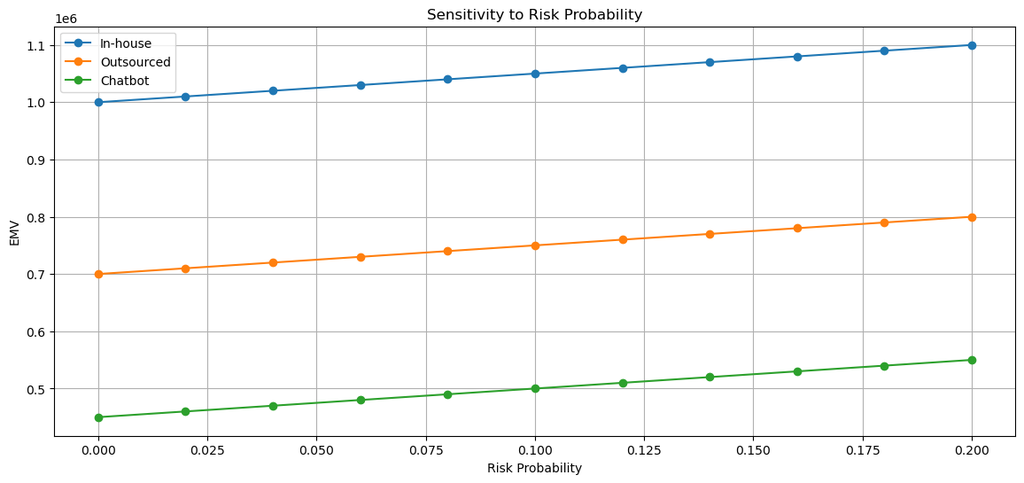

```python
import numpy as np
import matplotlib.pyplot as plt

costs = {
    "in_house": 1000000,
    "outsourced": 600000,
    "chatbot": 300000
}

risks = {
    "in_house": (0.05, 500000),
    "outsourced": (0.15, 500000),
    "chatbot": (0.10, 500000)
}

quality_costs = {
    "in_house": 0,
    "outsourced": 100000,
    "chatbot": 150000
}

# Here we do the sensitivity analysis for risk probabilities

risk_probabilities = np.linspace(0, 0.2, 11)
emv_in_house_probs = []
emv_outsourced_probs = []
emv_chatbot_probs = []

for prob in risk_probabilities:
    emv_in_house_probs.append(costs['in_house'] + quality_costs['in_house'] + (prob * risks['in_house'][1]))
    emv_outsourced_probs.append(costs['outsourced'] + quality_costs['outsourced'] + (prob * risks['outsourced'][1]))
    emv_chatbot_probs.append(costs['chatbot'] + quality_costs['chatbot'] + (prob * risks['chatbot'][1]))

# Here we are plotting the sensitivity analysis for risk probabilities

plt.figure(figsize=(14, 6))

plt.plot(risk_probabilities, emv_in_house_probs, label='In-house', marker='o')
plt.plot(risk_probabilities, emv_outsourced_probs, label='Outsourced', marker='o')
plt.plot(risk_probabilities, emv_chatbot_probs, label='Chatbot', marker='o')

plt.xlabel('Risk Probability')
plt.ylabel('EMV')
plt.title('Sensitivity to Risk Probability')
plt.legend()
plt.grid(True)
plt.show()
```

The graphs show that as the probability of losing high-value clients increases, the EMV for each strategy also increases. However, the chatbot strategy consistently maintains a lower EMV compared to the in-house and outsourced strategies across the entire range of probabilities (0 to 0.2).